# **An Evaluation of House Prices Market**

### Applying Data Science Life Cycle on Housing Prices

[figure not shown]

**Brianna Giang, Christopher Giang, Tony Vu**

### Table of Contents

- Introduction
- Part 1: Data Collection
- Part 2: Data Processing/Cleaning
- Part 3: Exploratory Data Analysis/Data Visualizations
- Part 4: Analysis, Hypothesis Testing, and Machine Learning
- Part 5: Insight and Policy Decision

## Introduction

Zillow is the USA's leading online real estate marketplace used for buying and selling homes. The pricing of a house is based on several factors, including but not limited to: the amount of space, the location, and the number of bedrooms and bathrooms. Zillow gets their information from a "municipal office responsible for recording real estate transactions in your area" (Zillow, 2023). In other words, all of their pricing information is based on public records. We could look through this information ourselves to determine a price estimate for a house given it's features; however, it would take too long to track down each record of houses similar to the one we're trying to estimate, and it would be even worse if we had to do it for multiple properties. Additionally, it is unnecessary to manually look through public records since we have the power of machine learning and data science at our disposal!" Why is this important? By leveraging ML and Data Science, we can save ourselves time when trying to figure out estimate pricing for a home given its features. We will seek to identify the factors that contribute to the house market prices by looking through USA Zillow House Listing of 2023. We will determine which factors are correlated between the changes of prices. This tutorial will cover the entire data science lifecycle, from data collection all the way to conclusive findings.  
If you are interested in finding out more about the how the pricing of homes are determined, go here: https://www.bankrate.com/real-estate/fair-market-value/  
Not only does the pricing of homes comes down to these factors, but there is another major factor in determining the pricing of homes, the market itself. If you would like to learn more about how the market impacts the pricing of homes, go here: https://www.investopedia.com/ask/answers/040215/how-does-law-supply-and-demand-affect-housing-market.asp

## Tools:

In order to start this project, we must first download Python. Why? Because Python is the top programming language used by data scientists on almost every website you see. To get help installing Python, you can visit this link in order to get started: [How to install Python](https://kinsta.com/knowledgebase/install-python/) or you can download it [here](https://www.python.org/downloads/) if you already know what you're doing. We are using Jupyter Notebook to write this tutorial which you can learn how to set up [here](https://jupyter.org/install) on the IDE of your choice.

## Libraries:

Pandas: Used for data manipulation and analysis. In this tutorial, we use their data frame whose documentation can be found [here](https://pandas.pydata.org/docs/). To learn more about what Pandas is, click [here!](https://www.nvidia.com/en-us/glossary/pandas-python/)  
Numpy: Used for data manipulation and statistical operations on our data frame. To see all of what NumPy can do, they have fantastic [documentation](https://numpy.org/doc/) on all of their functions. To learn more about what NumPy is click [here](https://www.nvidia.com/en-us/glossary/numpy/). Data Plotting! We use Matplotlib and Seaborn to get visual representations of our data. Through these graphs, we are able to analyze our information to determine what data we should be including to train our model. Here are the documentation pages for each of the plotting libraries if you want to learn more about all the types of graphs you could make using these libraries. [Matplotlib](https://matplotlib.org/3.8.3/index.html)  
[Seaborn](https://seaborn.pydata.org/)

## Part 1: Data Collection

First off we start with importing our data. Our analysis will be conducted on a national level. We will start by importing the relevant Python libraries for this study.

```python
# These are standard Python libraries when doing machine learning analysis.
import pandas as pd
import numpy as np
from sklearn.linear_model import LinearRegression
import statsmodels.api as sm
from sklearn.metrics import mean_absolute_error

# These libraries are used for plots and visualizations.
import matplotlib.pyplot as plt
import seaborn as sns
```

Our dataset came from [Kaggle](https://www.kaggle.com/datasets/febinphilips/us-house-listings-2023/data) , sourced from Zillow, a leading online platform for real estate transactions giving information on approximately 100 million homes. It's a comprehensive dataset covering various housing attributes across different regions of the United States, encompassing states, cities, and neighborhoods. This dataset offers valuable perspectives on real estate patterns and property attributes. Each entry corresponds to an individual property listing, containing information like location, property details, market valuations, and additional specifications.

Download the dataset from Kaggle to be able to import it.

```python
# This is how you import the CSV file.
df = pd.read_csv("zillow_housing_prices.csv")

# Showcasing the first five row of observations.
print(df.head())

row_count = len(df)

# Printing the number of rows
print("\n")
print(f'The Dataset has {row_count} observations.')
```

```
  State         City             Street  Zipcode   Latitude  Longitude  \
0    AL     Saraland           Scott Dr  36571.0  30.819534 -88.095960
1    AL    Southside       Big Oak Dr W  35907.0  33.881050 -86.012436
2    AL  Robertsdale    Cowpen Creek Rd  36567.0  30.590004 -87.580376
3    AL  Gulf Shores  Spinnaker Dr #201  36542.0  30.284956 -87.747920
4    AL      Chelsea         Mallet Way  35043.0  33.357986 -86.608700

   Bedroom  Bathroom    Area        PPSq  LotArea  ConvertedLot LotUnit  \
0      4.0       2.0  1614.0  148.636927  0.38050       0.38050   acres
1      3.0       2.0  1474.0    0.000678  0.67034       0.67034   acres
2      3.0       2.0  1800.0  144.388889  3.20000       3.20000   acres
3      2.0       2.0  1250.0  274.000000      NaN           NaN     NaN
4      3.0       3.0  2224.0  150.629496  0.26000       0.26000   acres

   MarketEstimate  RentEstimate     Price
0        240600.0        1599.0  239900.0
1        186700.0        1381.0       1.0
2             NaN           NaN  259900.0
3             NaN           NaN  342500.0
4        336200.0        1932.0  335000.0


The Dataset has 24521 observations.
```

Our different features in the data set are:

- **State**: The state in which the property is located (AL:Alabama) . Includes all US states except Hawaii.
- **City**: The city where the property is situated.
- **Street**: The street address of the property.
- **Zipcode**: The postal code associated with the property.
- **Bedroom**: The number of bedrooms in the house.
- **Bathroom**: The number of bathrooms in the house.
- **Area(sqft)**: The total area of the house.
- **PPSq(Price Per Square Foot)**: The cost per square foot of the property.
- **LotArea(acres)**: The total land area associated with the property.
- **Market Estimate(US Dollars)**: Estimated market value of the property. This value is estimated using Zillow's own algorithm.
- **Rent Estimate(US Dollars)**: Estimated rental value of the property. This value is estimated using Zillow's own algorithm.
- **Latitude**: The latitude coordinates of the property.
- **Longitude**: The longitude coordinates of the property.
- **Listed Price(US Dollars):** The listed price of the property.

## Part 2: Data Processing/Cleaning

Now that we imported our data. First we're going to clean our data to be usable and make sure it's relevant to our mission.

Our main goal is to predict the house market estimates. Thus, we will drop city and street because they are too specific for our purposes. We only want an overall estimate of house prices per state.

Out of Area, PPSq, LotArea, Lot Unit, and Converted Lot, we will be dropping Lot Area, Lot Unit and Converted because that gives us the total land area in acres. Since we already have area in square feet, we do not need any of those columns to keep it consistent.

Out of Listed Price, Market Estimate, and Rent Estimate, we are dropping Listed Price because that's the last listed price of the property. We are only interested in predicting the market estimate of houses so we will drop Rent Estimate as well.

We will also drop Latitude and Longitude because those aren't relevant to estimating the market price if we keep the states.

```python
df.drop(columns=['City', 'Street', 'Zipcode', 'Latitude','Longitude', 'LotArea', 'LotUnit', 'ConvertedLot', 'RentEstimate', 'Price'], inplace = True)
print(df.columns)
```

```
Index(['State', 'Bedroom', 'Bathroom', 'Area', 'PPSq', 'MarketEstimate'], dtype='object')
```

The next concern we have about cleaning our data is missing data. We have some missing values like NAN's in our Market Estimate. Our other columns also have missing data.

First we'll classify our missing data to the three categories of Missing Completely at Random (MCAR), Missing at Random (MAR), and Missing Not at Random (MNAR) scenarios. More information on missing data classifcation can be read [here](https://www.ncbi.nlm.nih.gov/books/NBK493614/) .

Some of the data in the columns such as Bedroom, Bathroom, and Area have missing values for features due to rare cases or listings not providing the data. This can be considered Missing Completely at Random (MCAR), because the data isn't related to the other observed or unobserved variables int he dcataset.

The missingingness in "MarketEstimate" can be considered Missing at Random (MAR) if it's related to other observed variables in the dataset. For instance, the missingingness could be due to Zillow choosing not to provide estimates based on certain characteristics of the properties (like location or size), then the missingness of these values is related to observed variables in the dataset.

There are several ways you can approach missing data. We could conduct missing point imputation which replace missing data with substitute values based on its closest neighbors. Or we could deal with missing data by just dropping the relevant rows.

Looking at our missing data, since we have several rows of data (24521 rows), we can afford to just drop the rows of missing data. We don't want to overfit our model later on the data.

```python
# Dropping all rows with missing data
df.dropna(inplace = True)
print(df.head())
```

```
  State  Bedroom  Bathroom    Area        PPSq  MarketEstimate
0    AL      4.0       2.0  1614.0  148.636927        240600.0
1    AL      3.0       2.0  1474.0    0.000678        186700.0
4    AL      3.0       3.0  2224.0  150.629496        336200.0
5    AL      3.0       2.0  1225.0  204.081633        222700.0
6    AL      3.0       2.0  1564.0   96.547315        150500.0
```

The next step to cleaning our data is treating our outliers. If we sort our data by the MarketEstimate prices, you can observe the range by showcasing the first five rows and the last five rows.

```python
# Sorting the data by market estimate values
df.sort_values(by=['MarketEstimate'], inplace = True)
print(df.head())
print(df.tail())
```

```
     State  Bedroom  Bathroom    Area        PPSq  MarketEstimate
9164    MD      4.0       3.0  2300.0   56.478261         15700.0
471     AL      4.0       2.0  1089.0  117.079890         21400.0
1900    AR      3.0       1.0  1524.0   16.076115         22500.0
8228    LA      4.0       2.0  2707.0    9.235316         24531.0
7725    KY      2.0       2.0  1105.0   24.886878         25900.0
      State  Bedroom  Bathroom     Area         PPSq  MarketEstimate
9949     MA      9.0      11.0  23374.0  1197.912210      27766800.0
24095    WY      5.0       7.0   7984.0  4101.953908      28174700.0
2422     CA      7.0       9.0  14000.0  2063.428571      28572600.0
24268    WY      4.0       7.0   9696.0  3867.574257      31759700.0
20183    TN      5.0      10.0  19811.0  2019.080309      36876900.0
```

As you can see above, the ranges for the markest estimate is very large. The range currently is 15,700 to 36,876,900. We want to do a more accurate and average prediction for our housing prices. According to [Forbes](https://www.forbes.com/advisor/mortgages/real-estate/median-home-prices-by-state/) , the average house price in the United States was 495,100 in the second quarter of 2023, according to the Census Bureau and Department of Housing and Urban Development.

To decide what range we should change the pricing too, we'll plot a boxplot to see the distributions of prices and where the averages lay.

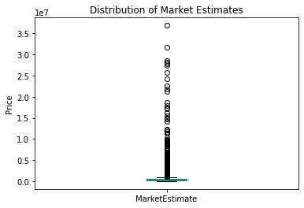

```python
# Plotting the market estimate price distribution boxplot

plt.rcParams.update({'font.size': 10})

df.boxplot(column='MarketEstimate', grid=False)
plt.title('Distribution of Market Estimates')
plt.ylabel('Price')
plt.show()
```

Looking at this box plot, the small circles indicate outliers. There are a lot of high outliers above the 1,000,000 range. At first we'll try aiming our range from 100,000 to 1,000,000 range and then look at a histogram of the distribution of prices to see the finer details and frequency of the points.

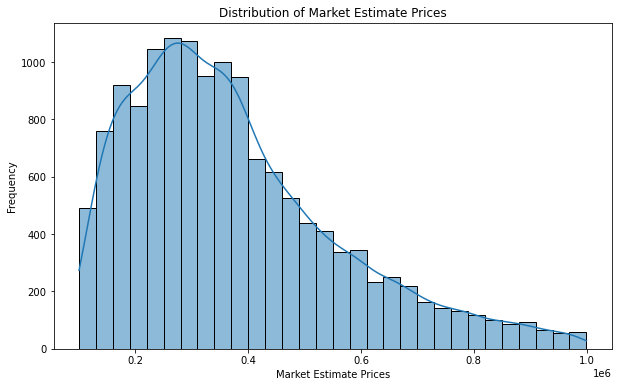

```python
# Restricting the data to market estimate prices of $100,000 to $1,000,000
df = df[(df['MarketEstimate'] >= 100000) & (df['MarketEstimate'] <= 1000000)]

# Plotting a histogram of the price distribution
plt.figure(figsize=(10, 6))
sns.histplot(df['MarketEstimate'], bins=30, kde=True)
plt.title('Distribution of Market Estimate Prices')
plt.xlabel('Market Estimate Prices')
plt.ylabel('Frequency')
plt.show()
```

## Part 3: Exploratory Data Analysis/Data Visualizations

In the Exploratory Data Analysis step, we want to observe the overall trends in our data. Let's explore the different factors. First, we'll examine the most common frequencies for the columns of State, Bedroom, and Bathroom to identify the majority values.

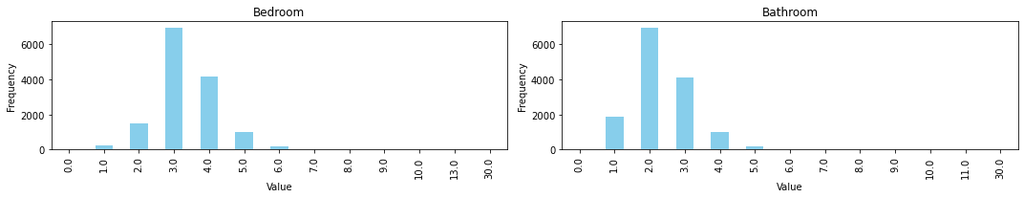

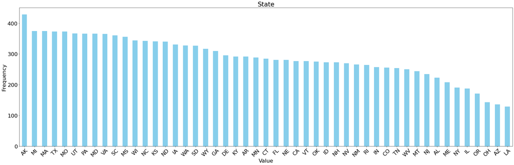

```python
# Due to some datapoints being half of a bathroom or bedrooms, for easier visualization and estimates,
# we choose to round them to have whole rooms.
df['Bathroom'] = np.round(df['Bathroom']).astype(float)
df['Bedroom'] = np.round(df['Bedroom']).astype(float)

# Create subplots for bedroom and bathroom plots
fig, axes = plt.subplots(nrows=2, ncols=2, figsize=(15, 5))

# Plot histograms for Bedroom and Bathroom in the first row
for i, column in enumerate(['Bedroom', 'Bathroom']):
    df[column].value_counts().sort_index().plot(kind='bar', ax=axes[0,i], color='skyblue')
    axes[0, i].set_title(column)
    axes[0, i].set_xlabel('Value')
    axes[0, i].set_ylabel('Frequency')

# Deleting the extra empty subplots
fig.delaxes(axes[1,0])
fig.delaxes(axes[1,1])

plt.tight_layout()
plt.show()

# Plot histogram for states
plt.rcParams.update({'font.size': 22})

plt.figure(figsize=(30, 10))
df['State'].value_counts().plot(kind='bar', color='skyblue')
plt.title('State')
plt.xlabel('Value')
plt.ylabel('Frequency')
plt.xticks(rotation=45)
plt.tight_layout()
plt.show()
```

We can also see there outliers for the numbers of bedrooms and bathrooms. We will restrict those numbers to make our data more reliable. We'll have no more than 6 bedrooms and bathrooms.

```python
df = df[(df['Bedroom'] <= 6)]
df = df[(df['Bathroom'] <= 6)]
```

Another way we can visualize the distribution of the states is through the violin plot. [Violin plots](https://mode.com/blog/violin-plot-examples) are used when you want to observe the distribution of numeric data, and are especially useful when you want to make a comparison of distributions between multiple groups. Thus, we can see the different estimated house market prices for each state.

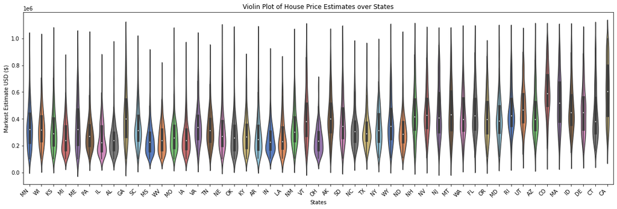

```python
plt.rcParams.update({'font.size': 10})

# Plotting a violin plot of the market estimate prices for each state
sns.violinplot(x = "State", y = "MarketEstimate", data=df, palette="muted")
plt.xlabel("States")
plt.ylabel("Markest Estimate USD ($)")
plt.title("Violin Plot of House Price Estimates over States")

# Rotate x-axis labels for better readability and adjust figure size
plt.xticks(rotation=45, ha='right')
plt.gcf().set_size_inches(20, 6)
plt.show()
```

The other features we will observe are the Area and PPSq features. We will plot a box plot to see the overall distribution and ranges of these features.

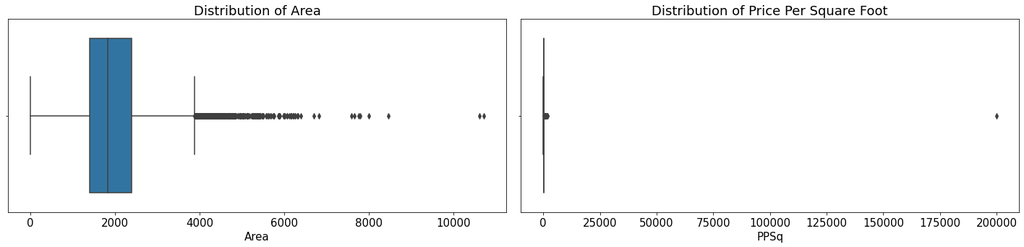

```python
# Plotting the different box plots for areas and price per square foot

# Changing the font size
plt.rcParams.update({'font.size': 15})

fig, axes = plt.subplots(nrows=1, ncols=2, figsize=(20, 5))

# Plotting the box plot for the area distribution
sns.boxplot(x=df['Area'], ax=axes[0], orient='h')
axes[0].set_title('Distribution of Area')

# Plotting the box plot for the price per square feet distribution
sns.boxplot(x=df['PPSq'], ax=axes[1], orient='h')
axes[1].set_title('Distribution of Price Per Square Foot')

# Adjust layout
plt.tight_layout()

# Show plot
plt.show()
```

Now, looking at the distribution of price per square foot, we can't see anything! There is a huge outlier to the point we can't even see the distribution. We will cut off that extreme value so it doesn't skew our data and we can get a better estimate of our box plot.

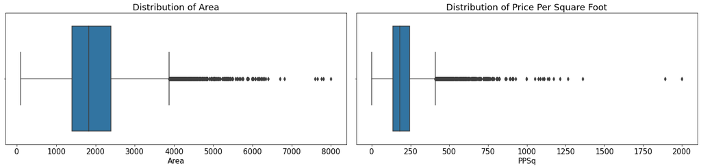

```python
# Changing the range of our areas
df = df[(df['Area'] <= 8000)]

# Restricting our price per square foot to be less than 25,000 to get rid of the extreme outlier.
df = df[(df['PPSq'] <= 25000)]

# Plotting the different box plots for areas and price per square foot

# Changing the font size
plt.rcParams.update({'font.size': 15})

fig, axes = plt.subplots(nrows=1, ncols=2, figsize=(20, 5))

# Plotting the box plot for the area distribution
sns.boxplot(x=df['Area'], ax=axes[0], orient='h')
axes[0].set_title('Distribution of Area')

# Plotting the box plot for the price per square feet distribution
sns.boxplot(x=df['PPSq'], ax=axes[1], orient='h')
axes[1].set_title('Distribution of Price Per Square Foot')

# Adjust layout
plt.tight_layout()

# Show plot
plt.show()
```

Now we can see a better distribution of our price per square foot. It's around the 100-250 USD range. We'll add one last line of code to cut off a few of the outliers that are above 1250.

```python
# Restricting our price per square foot to be less than 1,250 to get rid of the extreme outlier.
df = df[(df['PPSq'] <= 1250)]
```

Yay! Now that we finished looking at the general trends of all our features. Now let's look at some visualizations that will help us see how our features are connected to estimating house market prices.

The first thing we can do is a simple heat map to see the correlation of all our remaining variables.

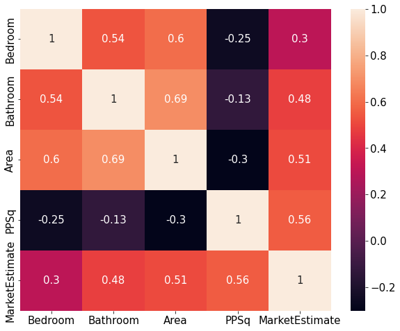

```python
df_numeric = df.drop(columns=['State'])
plt.figure(figsize=(10, 8))
sns.heatmap(df_numeric.corr(), annot=True)
plt.show()
```

This gives us a nice general summary of some possible correlations between our variables. However, we are mainly interested in predicting our estimated house market price.

So to see how the bathroom and bedrooms are related to our estimate house market prices, we will group the bathroom and bedrooms based on their number of rooms. Then we'll calculate the average estimated house price per group to see the trend.

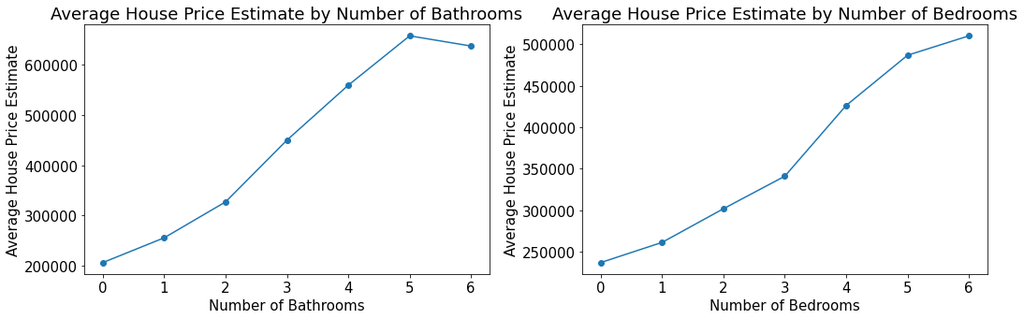

```python
# Plotting the average estimated house price based on bathroom groups

# Group by bathrooms and calculate average price for each group
avg_prices_by_bathrooms = df.groupby('Bathroom')['MarketEstimate'].mean().reset_index()

# Plotting the line graph
plt.figure(figsize=(15, 5))

# First subplot for bathroom groups
plt.subplot(1, 2, 1)
plt.plot(avg_prices_by_bathrooms['Bathroom'], avg_prices_by_bathrooms['MarketEstimate'], marker='o')
plt.title('Average House Price Estimate by Number of Bathrooms')
plt.xlabel('Number of Bathrooms')
plt.ylabel('Average House Price Estimate')

# Plotting the average estimated house price based on bedroom groups

# Group by 'bedrooms' and calculate average price for each group
avg_prices_by_bedrooms = df.groupby('Bedroom')['MarketEstimate'].mean().reset_index()

# Second subplot for bedroom groups
plt.subplot(1, 2, 2)
plt.plot(avg_prices_by_bedrooms['Bedroom'], avg_prices_by_bedrooms['MarketEstimate'], marker='o')
plt.title('Average House Price Estimate by Number of Bedrooms')
plt.xlabel('Number of Bedrooms')
plt.ylabel('Average House Price Estimate')

# Adjust layout
plt.tight_layout()

# Show the plot
plt.show()
```

We can see an increasing trend here where as the numbers of bathrooms increase, the average house price estimate increases. We can also see an increasing trend as the number of bedrooms increase, the average house price estimate increases. This seems to suggest a linear type of relationship between these features.

Now let's see the relationship between the area sizes/price per square feet and average estimated house market prices.

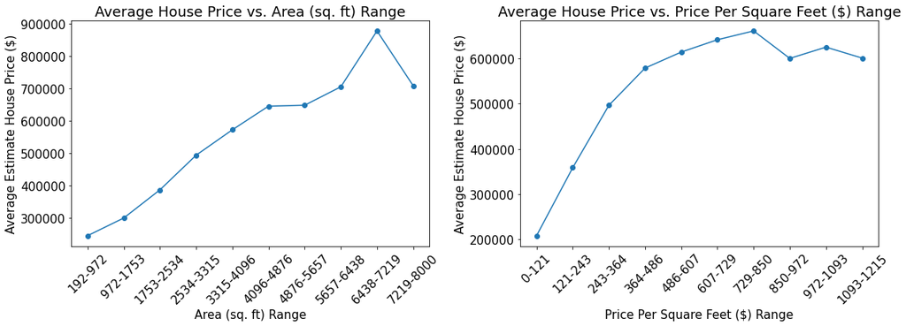

```python
# This function will create ranges out of the values given and then plot the ranges against the average estimated house price.
def plot_avg_price_by_range(df, column_name, xlabel):
    # Determine min and max values of the specified column
    min_val = df[column_name].min()
    max_val = df[column_name].max()

    # Define the number of bins
    num_bins = 10

    # Create bins based on min and max values
    bins = np.linspace(min_val, max_val, num_bins + 1)

    # Create labels for the bins
    labels = [f'{int(bins[i])}-{int(bins[i+1])}' for i in range(len(bins) - 1)]

    # Create a new column 'range' based on the bins
    range_column = f'{column_name}_range'
    df[range_column] = pd.cut(df[column_name], bins=bins, labels=labels, include_lowest=True)

    # Group by 'range' and calculate average house price for each group
    avg_price_by_range = df.groupby(range_column)['MarketEstimate'].mean().reset_index()

    # Plotting the line graph
    plt.plot(avg_price_by_range[range_column], avg_price_by_range['MarketEstimate'], marker='o', linestyle='-')

    # Adding labels and title
    plt.title(f'Average House Price vs. {xlabel} Range')
    plt.xlabel(f'{xlabel} Range')
    plt.ylabel('Average Estimate House Price ($)')
    plt.xticks(rotation=45)


# Create a figure and two subplots side by side
fig, axes = plt.subplots(1, 2, figsize=(16, 6))

# Plotting Average House Price vs. Area Range
plt.sca(axes[0])
plot_avg_price_by_range(df, 'Area', 'Area (sq. ft)')

# Plotting Average House Price vs. Price Per Square Feet Range
plt.sca(axes[1])
plot_avg_price_by_range(df, 'PPSq', 'Price Per Square Feet ($)')

# Adjust layout and display the plot
plt.tight_layout()
plt.show()
```

## Part 4: Analysis, Hypothesis Testing, and Machine Learning

Our first step is using Hypothesis Testing to determine if our features have a statistical signifiance to our estimating house prices. First we will establish our hypothesis we are testing.

**Null Hypothesis**: The state, number of bathrooms, number of bedrooms, amount of square feet in area, and price per square feet is not statistically significant enough to affect the estimated market price of a house.

**Alternative Hypothesis**: The state, number of bathrooms, number of bedrooms, amount of square feet in area, and price per square feet is statistically significant enough to affect the estimated market price of a house.

Then we will use the statsmodels.api library to run a hypothesis test and analyze our OLS Regression result.

One thing to take notice of is that our State variable is a categorical variable. We have to encode this categorical variable to include it in our multiple linear regression model. One common method is to use one-hot encoding, which transforms categorical variables into a set of binary (0 or 1) variables representing each category. Thus we'll do this by converting our state variable into a dummy variable. To learn more about dummy variables, you can read more about it [here](https://mtab.com/blog/what-are-dummy-variables) .

```python
# numerical independent variables
X_numerical = df[['Bathroom', 'Bedroom', 'Area', 'PPSq']]
# Getting dummy variables out of state
state_dummies = pd.get_dummies(df['State'], drop_first=True)

# Combine numerical variables and dummy variables
X = pd.concat([X_numerical, state_dummies], axis=1)

# Add a constant term to the independent variables matrix
X = sm.add_constant(X)

# Dependent variable
y = df['MarketEstimate']

# Fit the multiple linear regression model
model = sm.OLS(y, X).fit()

# Get the model summary as a string
summary_str = model.summary().as_text()

# Split the summary string into lines
summary_lines = summary_str.split('\n')

# Print the lines necessary to showcase some of the states
print("\n".join(summary_lines[:30]))
```

```
                            OLS Regression Results
==============================================================================
Dep. Variable:         MarketEstimate   R-squared:                       0.834
Model:                            OLS   Adj. R-squared:                  0.833
Method:                 Least Squares   F-statistic:                     1353.
Date:                Tue, 14 May 2024   Prob (F-statistic):               0.00
Time:                        15:16:56   Log-Likelihood:            -1.7826e+05
No. Observations:               14082   AIC:                         3.566e+05
Df Residuals:                   14029   BIC:                         3.570e+05
Df Model:                          52
Covariance Type:            nonrobust
==============================================================================
                 coef    std err          t      P>|t|      [0.025      0.975]
------------------------------------------------------------------------------
const      -2.457e+05   5077.599    -48.395      0.000   -2.56e+05   -2.36e+05
Bathroom    2.652e+04   1106.794     23.961      0.000    2.44e+04    2.87e+04
Bedroom      1.06e+04    942.493     11.245      0.000    8750.764    1.24e+04
Area         139.4513      1.248    111.710      0.000     137.004     141.898
PPSq        1290.5190      8.148    158.384      0.000    1274.548    1306.490
AL         -4.071e+04   6359.048     -6.402      0.000   -5.32e+04   -2.82e+04
AR          -2.92e+04   5834.875     -5.005      0.000   -4.06e+04   -1.78e+04
AZ          1.859e+04   7506.959      2.476      0.013    3870.920    3.33e+04
CA          3.791e+04   5991.317      6.328      0.000    2.62e+04    4.97e+04
CO          4.627e+04   6067.622      7.626      0.000    3.44e+04    5.82e+04
CT          1.019e+04   5833.653      1.747      0.081   -1243.869    2.16e+04
DE          5865.2611   5769.322      1.017      0.309   -5443.377    1.72e+04
FL          1.911e+04   5864.148      3.258      0.001    7612.531    3.06e+04
GA         -1.605e+04   5716.759     -2.807      0.005   -2.73e+04   -4842.558
IA         -3.608e+04   5636.682     -6.401      0.000   -4.71e+04    -2.5e+04
ID           1.98e+04   5928.306      3.340      0.001    8180.427    3.14e+04
```

The important column to see here is our P-Value. We can see that in most of our feature variables columns such as Bedroom, Bathroom, Area, PPSq, the P-Value is 0.00. We will reject the null hypothesis of no relationship between these features and our estimated house market price because we have a small p-value of 0.00. This would be able to pass a test with 0.10, 0.05, or 0.01 significance levels. The p-value is lower than all these significance values.

This is a good start to realize that our feature are significant!

Looking at the state feature p-values, they differ which makes sense because buying a house would vary the price in each state. You should stay mindful of estimating the house price based on the state. A common data science technique is to provide an [interaction term](https://developer.nvidia.com/blog/a-comprehensive-guide-to-interaction-terms-in-linear-regression/#:~:text=An%20important%2C%20and%20often%20forgotten,value%20of%20another%20independent%20variable) for the states to try to improve the performance. This would account for the joint effect within each state.

```python
# Select independent variables
X_numerical = df[['Bathroom', 'Bedroom', 'Area', 'PPSq']]

# Create dummy variables for the 'State' column
state_dummies = pd.get_dummies(df['State'], prefix='State', drop_first=True)

# Initialize an empty list to store individual interaction term dataframes
interaction_terms_list = []

# Iterate over each numerical variable and each state dummy variable to create interaction terms
for column in X_numerical.columns:
    for state in state_dummies.columns:
        # Perform multiplication to create the interaction term dataframe
        interaction_term = X_numerical[column] * state_dummies[state]

        # Rename the interaction between the specific column and state
        interaction_term.rename(f"{column}_{state}", inplace=True)

        # Append the interaction term dataframe to the list
        interaction_terms_list.append(interaction_term.to_frame())

# Concat all interaction terms
interaction_terms = pd.concat(interaction_terms_list, axis=1)

# Combine numerical variables, state dummies, and interaction terms
X = pd.concat([X_numerical, state_dummies, interaction_terms], axis=1)

# Add a constant term to the independent variables matrix
X = sm.add_constant(X)

# Dependent variable
y = df['MarketEstimate']

# Fit the multiple linear regression model
model = sm.OLS(y, X).fit()

# Get the model summary as a string
summary_str = model.summary().as_text()

# Split the summary string into lines
summary_lines = summary_str.split('\n')

# Print the lines necessary to understand the interaction term
print("\n".join(summary_lines[:20]))
print("\n".join(summary_lines[100:105]))
print("\n".join(summary_lines[150:155]))
```

```
                            OLS Regression Results
==============================================================================
Dep. Variable:         MarketEstimate   R-squared:                       0.877
Model:                            OLS   Adj. R-squared:                  0.875
Method:                 Least Squares   F-statistic:                     406.0
Date:                Tue, 14 May 2024   Prob (F-statistic):               0.00
Time:                        15:16:57   Log-Likelihood:            -1.7611e+05
No. Observations:               14082   AIC:                         3.527e+05
Df Residuals:                   13837   BIC:                         3.546e+05
Df Model:                         244
Covariance Type:            nonrobust
=====================================================================================
                        coef    std err          t      P>|t|      [0.025      0.975]
-------------------------------------------------------------------------------------
const             -3.286e+05   1.71e+04    -19.187      0.000   -3.62e+05   -2.95e+05
Bathroom           2.843e+04   5757.070      4.938      0.000    1.71e+04    3.97e+04
Bedroom            1.473e+04   4578.670      3.218      0.001    5759.947    2.37e+04
Area                162.9530      6.921     23.546      0.000     149.388     176.518
PPSq               1373.6987     45.245     30.362      0.000    1285.013    1462.385
State_AL           9.842e+04   3.13e+04      3.144      0.002    3.71e+04     1.6e+05
Bathroom_State_OK -1.851e+04   8778.700     -2.109      0.035   -3.57e+04   -1306.797
Bathroom_State_OR -8587.1219   1.08e+04     -0.797      0.426   -2.97e+04    1.25e+04
Bathroom_State_PA -2.419e+04   7920.234     -3.054      0.002   -3.97e+04   -8666.252
Bathroom_State_RI  -719.6188   9670.390     -0.074      0.941   -1.97e+04    1.82e+04
Bathroom_State_SC -1.017e+04   9261.365     -1.098      0.272   -2.83e+04    7985.763
Bedroom_State_PA  -1.749e+04   7378.786     -2.371      0.018    -3.2e+04   -3028.322
Bedroom_State_RI  -8454.5848   6865.175     -1.232      0.218   -2.19e+04    5002.087
Bedroom_State_SC  -1.498e+04   8021.383     -1.867      0.062   -3.07e+04     746.338
Bedroom_State_SD  -2836.3201   6241.117     -0.454      0.650   -1.51e+04    9397.114
Bedroom_State_TN    168.2441   7850.270      0.021      0.983   -1.52e+04    1.56e+04
```

Now this model accounts for the interaction term, and you can see specifically how each state will affect each feature. I didn't showcase all of the states because there was 50 but now you can gain a better understanding of which state is most significant. For example, since Bathroom and PA P-value is 0.002, it would be statistically significant in most significance levels of 0.10, 0.05, or 0.01.

The first thing we'll do is fit a regular Linear Regression model from the [scikit-learn library](https://scikit-learn.org/stable/modules/generated/sklearn.linear_model.LinearRegression.html) to get our fitted values.

```python
from sklearn.metrics import mean_squared_error
from sklearn.model_selection import train_test_split

# Step 1: Split Data into Training and Testing Sets
# features
X = df[['Bedroom', 'Bathroom', 'Area', 'PPSq']]
# target variable
y = df['MarketEstimate']

X_train, X_test, y_train, y_test = train_test_split(X, y, test_size=0.2, random_state=42)

# Instantiate and fit the Linear Regression model using scikit-learn
model = LinearRegression()
model.fit(X_train, y_train)

# Make predictions on the test set
y_pred = model.predict(X_test)

# Print actual and predicted values for the test set
num_samples_to_print = 10

print("Sample\tActual (Full Value)\tPredicted (Full Value)")
print("-----------------------------------")
for i in range(num_samples_to_print):
    # get the actual value
    actual_value = y_test.iloc[i]
    # get predicted value
    predicted_value = y_pred[i]
    print(f"{i+1}\t${actual_value:.2f}\t\t${predicted_value:.2f}")


print("\n")

# Evaluate the model using Mean Squared Error (MSE)
mse = mean_squared_error(y_test, y_pred)
print(f'Mean Squared Error (MSE): {mse:.5f}')
```

```
Sample	Actual (Full Value)	Predicted (Full Value)
-----------------------------------
1	$323200.00		$319118.51
2	$284300.00		$462515.72
3	$881600.00		$716999.21
4	$215700.00		$236248.61
5	$122400.00		$73767.08
6	$368600.00		$394820.62
7	$290000.00		$340187.06
8	$258300.00		$283698.90
9	$276200.00		$284596.23
10	$294800.00		$435831.92


Mean Squared Error (MSE): 7346931976.57781
```

**Yikes!** That's a very big mean square error. When we look at a small preview, it doesn't seem like there is a big difference in our actual values and predicted values, but the MSE seems to indicate there's a huge difference in the accuracy.

No worries, there are many ways we can improve our model in Machine Learning!

With a MSE this large, we can scale numerical features to a similar range using techniques like standardization.

[Standardization](https://www.analyticsvidhya.com/blog/2020/04/feature-scaling-machine-learning-normalization-standardization/) transforms the estimate house market price to have a mean of zero and a standard deviation of one, making it more robust to outliers and skewed distributions. This could aid our model in converging and ensures consistency in model evaluation.

Similarly, there can be a worry that our model is overfitting our data. Thus, to prevent this from occuring, we will switch from the regular Linear Regression model to using Ridge Regression Model with Regularization. [Ridge Regression](https://www.ibm.com/topics/ridge-regression) helps prevent overfitting of the data by adding penalty to any large coefficients, which thus helps make more accurate models that generalize better unseen data. Ridge Regression, is a regularization technique that helps correct for overfitting on training data. It adds a penalty term called the L2 norm to the loss function, which helps to shrink the large coefficients towards zero without fully eliminating them.

```python
from sklearn.linear_model import Ridge
from sklearn.metrics import mean_squared_error

# Get the average and standard deviation of the Market Estimate Price of House, then standardize
u = df['MarketEstimate'].mean()
o = df['MarketEstimate'].std()

df['StdMarketEstimate'] = (df['MarketEstimate'] - u) / o

# Step 1: Split Data into Training and Testing Sets
# features
X = df[['Bedroom', 'Bathroom', 'Area', 'PPSq']]
# target variable
y = df['StdMarketEstimate']

X_train, X_test, y_train, y_test = train_test_split(X, y, test_size=0.2, random_state=42)

# Step 2: Define and Train Ridge Regression Model with Regularization (alpha)
alpha = 1.0
ridge_model = Ridge(alpha=alpha)
ridge_model.fit(X_train, y_train)

# Step 3: Make Predictions on the Test Set
y_pred = ridge_model.predict(X_test)

# Step 4: Print Actual and Predicted Values from the Test Set
num_samples_to_print = 5

print("Sample\tActual (Full Value)\tPredicted (Full Value)")
print("-----------------------------------")
for i in range(num_samples_to_print):
    # Convert back to original scale
    actual_value = y_test.iloc[i] * o + u
    predicted_value = y_pred[i] * o + u
    print(f"{i+1}\t${actual_value:.2f}\t\t${predicted_value:.2f}")

print("\n")

# Step 5: Evaluate the Model using Mean Squared Error (MSE)
mse = mean_squared_error(y_test, y_pred)
print(f'\nMean Squared Error (MSE) with Ridge Regression (alpha={alpha}): {mse:.5f}')
```

```
Sample	Actual (Full Value)	Predicted (Full Value)
-----------------------------------
1	$323200.00		$319119.39
2	$284300.00		$462514.56
3	$881600.00		$716997.56
4	$215700.00		$236243.90
5	$122400.00		$73770.62



Mean Squared Error (MSE) with Ridge Regression (alpha=1.0): 0.21106
```

Let's try some other techniques out to help our prediction, like the Gradient Descent algorithm to help determine our weights and bias term. [Gradient Descent](https://builtin.com/data-science/gradient-descent) is an optimization technique used to locate a local minimum of a differentiable function. In the context of machine learning, Gradient Descent is employed to determine the parameter values (coefficients) of a function that minimize a given cost function to the greatest extent possible. This will help give us weights to try to minimize loss.

```
Bias -> -7.77967
Weights:
Bedroom: -13.42332
Bathroom: 1.21949
Area: 101.00105
PPSq: 942.85028
```

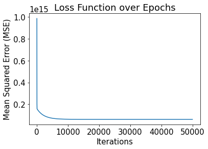

```python
# Step 1: Split Data into Training and Testing Sets
# Features
X = df[['Bedroom', 'Bathroom', 'Area', 'PPSq']]
df.drop(columns=['StdMarketEstimate'], inplace=True)
y = df['MarketEstimate']  # Target variable

X_train, X_test, y_train, y_test = train_test_split(X, y, test_size=0.2, random_state=42)

# To account for adding the bias term, augment X with a column of one's.
X = np.hstack((np.ones((X_train.shape[0], 1)), X_train))
y = y_train

# Hyperparameters
# iterations
T = 50000
# learning rate
alpha = 0.000000000001

def grad_descent(X, y, T, alpha):
    # m = # examples, n = # features
    m, n = X.shape
    # initialize parameters
    theta = np.zeros(n)
    # track loss over time
    f = np.zeros(T)
    for i in range(T):
        f[i] = 0.5 * np.linalg.norm(X.dot(theta) - y)**2
        g = np.transpose(X).dot(X.dot(theta) - y)
        theta = theta - alpha * g
    return theta, f

# Run gradient descent
theta, loss = grad_descent(X, y, T, alpha)
# Print out bias and weights
print(f'Bias -> {theta[0]:.5f}')
print(f'Weights:')

for col, weight in zip(['Bedroom', 'Bathroom', 'Area', 'PPSq'], theta[1:]):
    print(f'{col}: {weight:.5f}')
# Plotting the loss over the epochs
plt.plot(loss)
plt.xlabel("Iterations")
plt.ylabel("Mean Squared Error (MSE)")
plt.title("Loss Function over Epochs")
plt.show()
```

Looking at our loss function over epochs, there is a L shape indicating it's rapidly improving in reducing the loss as the iterations increase. This can indicate that our gradient descent is doing a good job at optimizing our parameters for our cost function.

```python
# Add a column of ones to X to represent the intercept term
X_test = np.hstack((np.ones((X_test.shape[0], 1)), X_test))
# Predict from X_test
y_test_pred = X_test.dot(theta)
# Calculate the mean squared error for Ridge Regression model
mse = np.mean((y_test - y_test_pred)**2)

for pred, actual in zip(y_test_pred[:5], y_test[:5]):
    print(f'Predicted: {pred:.5f}, Actual: {actual:.5f}')


# Print the mean squared error
print(f'Mean Squared Error: {mse:.5f}')
```

```
Predicted: 373954.84377, Actual: 323200.00000
Predicted: 457859.27663, Actual: 284300.00000
Predicted: 599542.67810, Actual: 881600.00000
Predicted: 292591.35093, Actual: 215700.00000
Predicted: 226978.37538, Actual: 122400.00000
Mean Squared Error: 10827381737.22535
```

**Oh no yikes again!** The Gradient Descent Algorithm from class still results in an extremely high Mean Squared Error, indicating how inaccurate the model is at predicting housing market estimate. Thus, the regression with gradient descent model is not a good model to use for prediction.

Now finally let's wrap our tutorial up with some insights and conclusions we made based on of our analysis and machine learning!

## Part 5: Insight and Policy Decision

Well there you have it! We have shown you the full data science pipeline (data collection, data preprocessing, exploratory data analysis, and machine learning along with hypothesis testing) for analyzing features of houses, their individual effects on prices and how we can use those feature to predice housing prices.

Data Collection Summary

In Part 1, we obtained housing data from a Kaggle Dataset that was sourced from Zillow, containing housing data for houses all across the U.S. From this dataset, we received insights into various housing features across different region in the U.S.

In Part 2, we conducted data processing and cleaned up the data. This was conducted through dropping irrelevant columns and by addressing missing data. By the end of this step we only kept columns: State, Bedroom, Bathroom, Area (sqft), PPSq, and Market Estimate.

## The End?

I hope you enjoyed this tutorial! :D  
Although there are still other factors that need to be taken into account when determining the pricing of homes in America. We know from this data science lifecycle that the number of bedrooms, number of bathrooms, area, and state are the more important factors. However, it is up to us (you and I!) as data scientists to retest new data regularly in order to keep track of trends within the housing market.